# read and plot xvg file

This document demonstrates how to use the **xvm** package and its functions with sample datasets and plots. It also shows how to read multiple xvg files and arrange their plots using ggpubr.

**Note**: Ensure dependency packages are installed:

```r
install.packages(c("ggplot2", "stringr", "ggpubr"))
```

### Load the xvm package and dependency packages

Load the xvm package:

```r
# Load the xvm package
library(xvm)
```

Load other dependency packages:

```r
# Load dependency packages
library(ggplot2)
```

## Read a single xvg file and plot it.

### Get Example File Path

Retrieve the path to the example file included in the package:

```r
# This example file is an xvg file containing RMSD data generated by GROMACS
rmsd_file_path <- system.file("extdata/rmsd.xvg", package = "xvm")
```

### Read the xvg file

```r
# Read the xvg file using read_xvg() function
rmsd_data <- read_xvg(rmsd_file_path)

# The imported xvg file is stored as a list, with the list name corresponding to the file name.
names(rmsd_data)
```

```
#> [1] "rmsd.xvg"
```

The imported xvg file is stored as a list, so you can simply display the data using the `str()` function.

```r
str(rmsd_data[[1]])
```

```
#> List of 2
#>  $ data    :'data.frame':    3334 obs. of  2 variables:
#>   ..$ Time (ps): num [1:3334] 0 30 60 90 120 150 180 210 240 270 ...
#>   ..$ RMSD (nm): num [1:3334] 0.000499 0.115534 0.127646 0.125452 0.123716 ...
#>  $ metadata:List of 9
#>   ..$ title            : chr "RMSD"
#>   ..$ subtitle         : chr "Backbone after lsq fit to Backbone"
#>   ..$ xaxis            : chr "Time (ps)"
#>   ..$ yaxis            : chr "RMSD (nm)"
#>   ..$ xaxis_formatted  : chr "Time (ps)"
#>   ..$ yaxis_formatted  : chr "RMSD (nm)"
#>   ..$ legends          : chr(0)
#>   ..$ legends_formatted: Named list()
#>   ..$ file_path        : chr "/private/var/folders/_b/gx4lc14d5ssf7pl9qlkl32r80000gn/T/RtmpbUT07a/Rinst8bfc13eb2f36/xvm/extdata/rmsd.xvg"
#>  - attr(*, "class")= chr "xvg_data"
```

The list contains two elements, each storing different pieces of information:

`$data`: a data frame containing the xvg data.

`$metadata`: other detailed information about the xvg file, including:

- *title*: the main title.
- *subtitle*: the subtitle.
- *xaxis*: the label for the x-axis.
- *yaxis*: the label for the y-axis.
- *xaxis_formatted*: the x-axis label formatted to support subscripts and superscripts.
- *yaxis_formatted*: the y-axis label formatted to support subscripts and superscripts.
- *legends*: the legend labels.
- *legends_formatted*: the formatted legend labels.
- *file_path*: the path where the file is located.

### Plot the xvg data

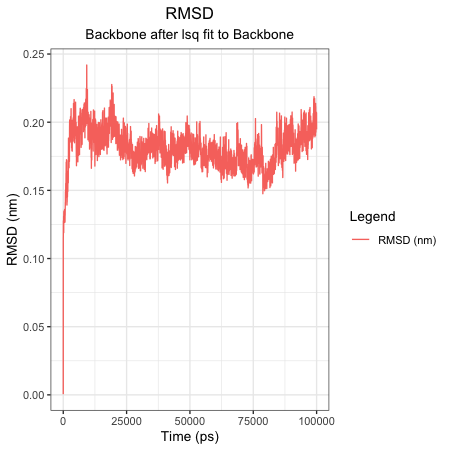

```r
# Plot the xvg data using plot_xvg() function
plot_xvg(rmsd_data)
```

## Read multiple xvg Files

The `read_xvg()` function can accept multiple xvg file paths as a character vector.

```r
# Similarly, you can also read multiple types of xvg files.
multi_file_path <- dir(system.file("extdata", package = "xvm"))

# Filter out xvg files using stringr package
library(stringr)
multi_file_path <- multi_file_path[str_detect(multi_file_path, ".xvg")]
print(multi_file_path)
```

```
#> [1] "rmsd.xvg" "rmsf.xvg"
```

```r
# Set the full xvg file paths
multi_file_path <- file.path(system.file("extdata", package = "xvm"),
                             multi_file_path
                             )
```

### Batch read xvg files

```r
# Read multiple xvg files at once in batch:
multi_data <- read_xvg(multi_file_path)
names(multi_data)
```

```
#> [1] "rmsd.xvg" "rmsf.xvg"
```

### Inspect a single xvg file

You can view the information of a single xvg file by indexing the list:

```r
# Check the first xvg file info via indexing
str(multi_data[[1]])
```

```
#> List of 2
#>  $ data    :'data.frame':    3334 obs. of  2 variables:
#>   ..$ Time (ps): num [1:3334] 0 30 60 90 120 150 180 210 240 270 ...
#>   ..$ RMSD (nm): num [1:3334] 0.000499 0.115534 0.127646 0.125452 0.123716 ...
#>  $ metadata:List of 9
#>   ..$ title            : chr "RMSD"
#>   ..$ subtitle         : chr "Backbone after lsq fit to Backbone"
#>   ..$ xaxis            : chr "Time (ps)"
#>   ..$ yaxis            : chr "RMSD (nm)"
#>   ..$ xaxis_formatted  : chr "Time (ps)"
#>   ..$ yaxis_formatted  : chr "RMSD (nm)"
#>   ..$ legends          : chr(0)
#>   ..$ legends_formatted: Named list()
#>   ..$ file_path        : chr "/private/var/folders/_b/gx4lc14d5ssf7pl9qlkl32r80000gn/T/RtmpbUT07a/Rinst8bfc13eb2f36/xvm/extdata/rmsd.xvg"
#>  - attr(*, "class")= chr "xvg_data"
```

### Plot a single xvg file

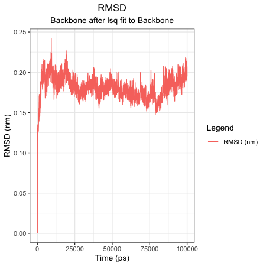

```r
# Plot one of the xvg files using the plot_xvg() function:
plot_xvg(multi_data[[1]])
```

### Plot multiple xvg files

Alternatively, use `lapply()` to generate plots for each xvg file:

```r
# Use lapply() to plot all the xvg files in batch
mutli_xvg_plots <- lapply(multi_data, plot_xvg)
```

### Arrange plots using ggpubr

Finally, arrange all plots into a single layout using the `ggarrange()` function from the ggpubr package:

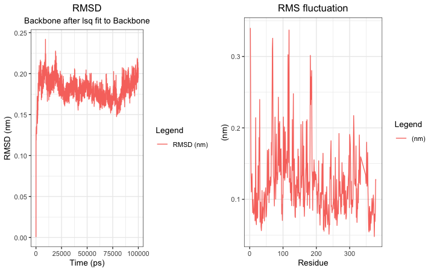

```r
# Arrange the plots using ggpubr
library(ggpubr)
ggarrange(plotlist = mutli_xvg_plots)
```